# OLWTEF

JJayes

05/09/2020

## How do we thrive?

### Share of population living in extreme poverty by region

Share of population living in extreme poverty by region: Thin dotted lines and legend

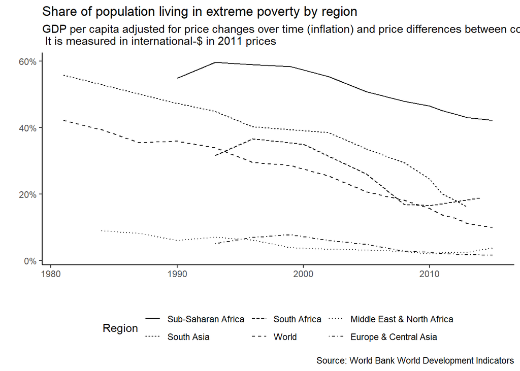

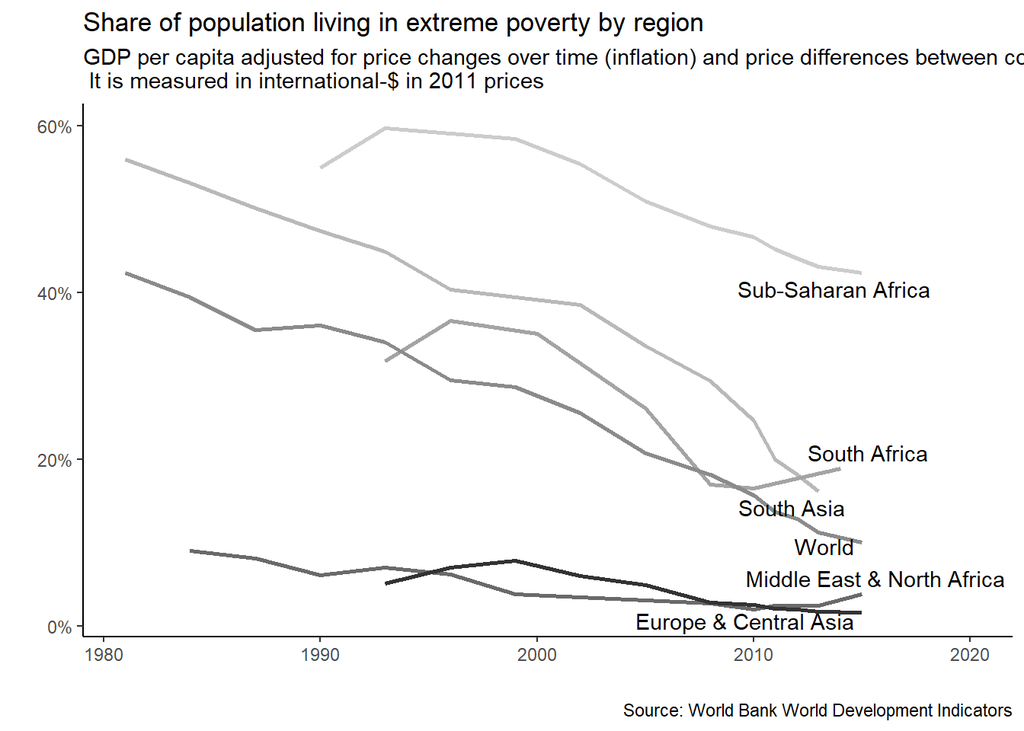

Share of population living in extreme poverty by region: Shaded thick dotted line and a legend

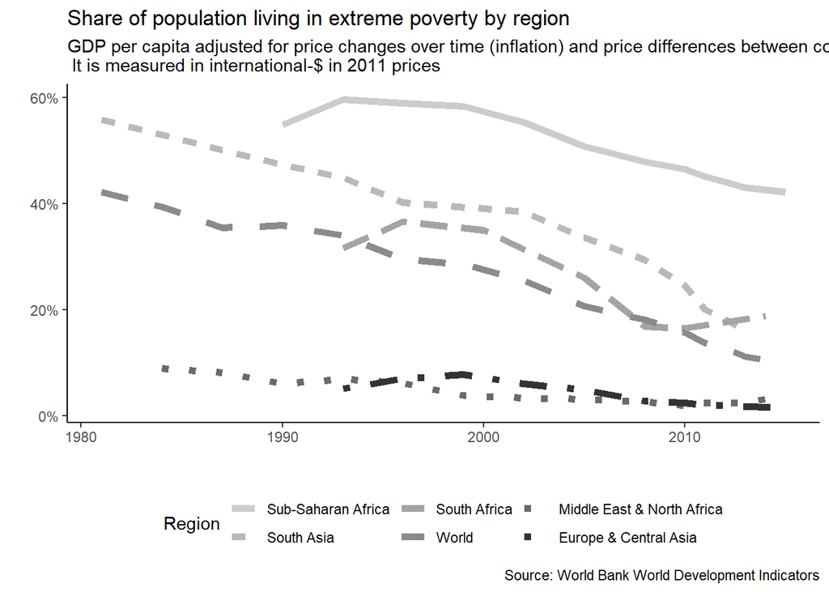

Share of population living in extreme poverty by region: Thinner dotted line and a legend

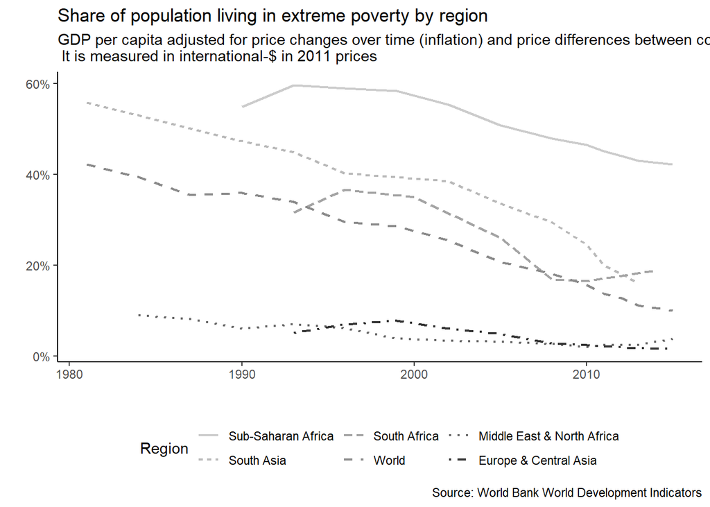

..

All of the following plots can be done with any selection of these styles, as you like the look most.

..

### Share of population living in absolute poverty

Share of population living in absolute poverty: Thick, dotted grey lines

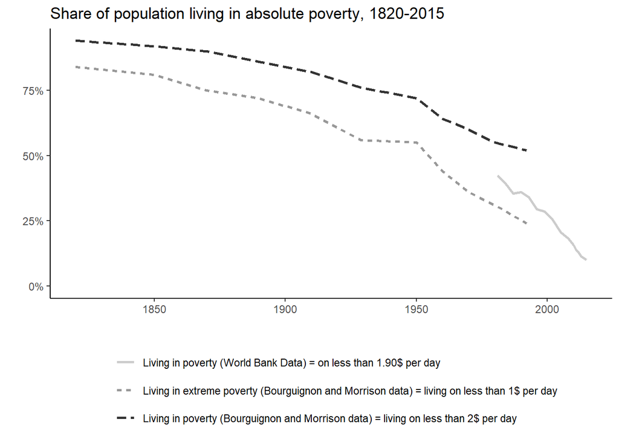

Share of population living in absolute poverty: Thin dotted lines

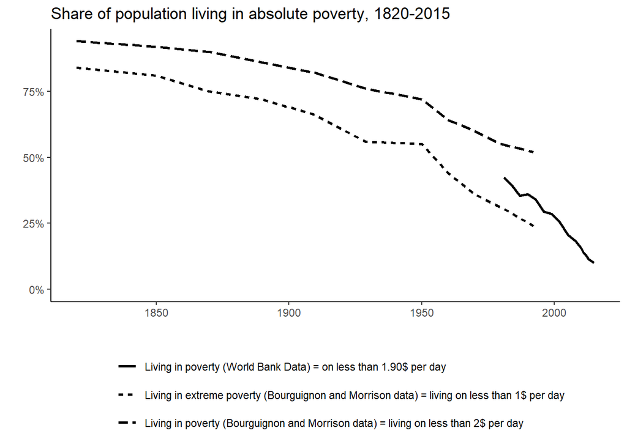

Share of population living in absolute poverty: shaded lines

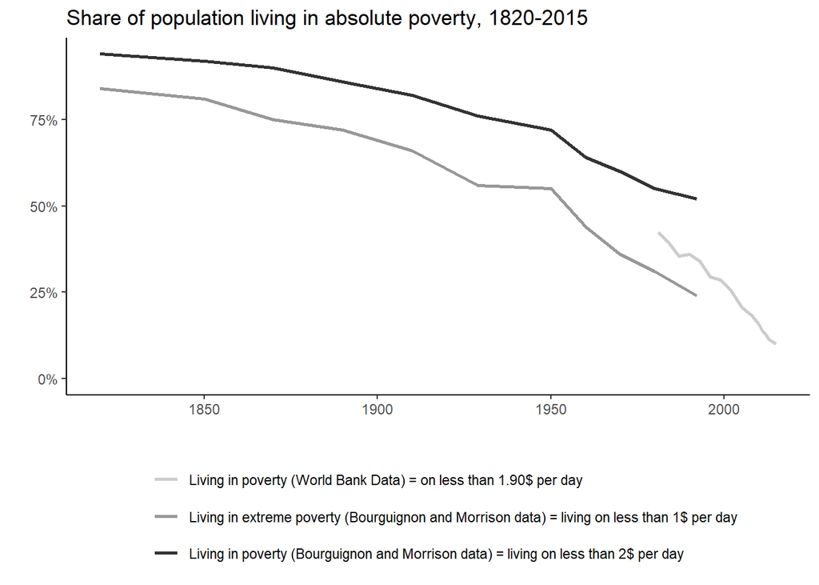

### GDP per capita growth

(Choice of countries here can be changed)

GDP per capita growth since 1700: Thin dotted lines, labels in pane and a legend.

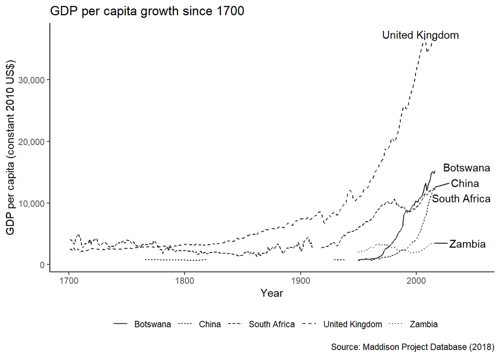

GDP per capita growth since 1700: Grey shading and legend

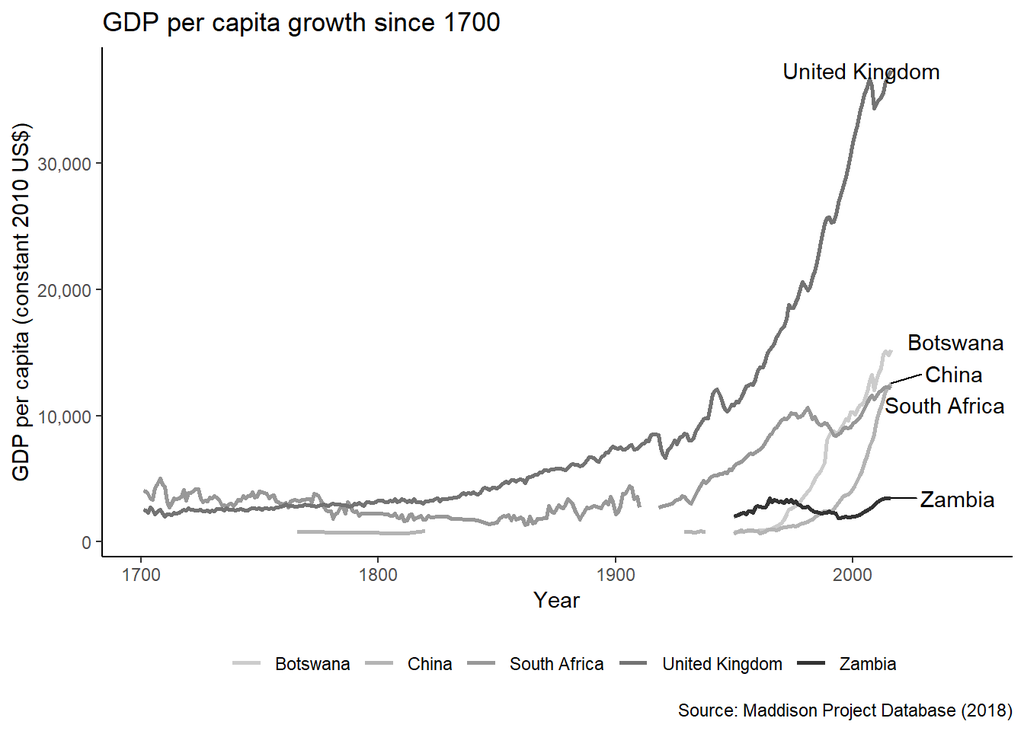

GDP per capita growth since 1700: Grey shading and dotted lines - no legend

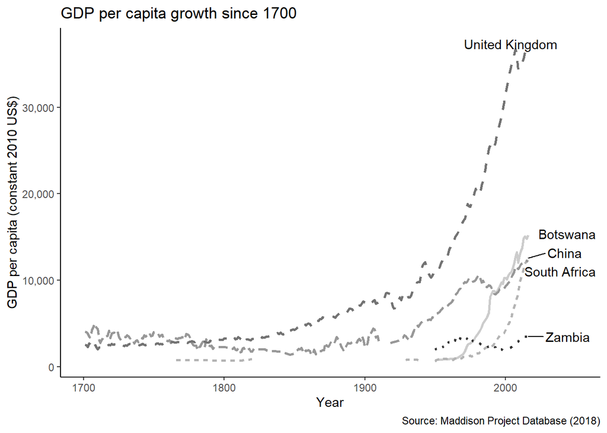

### Ashraf and Galor

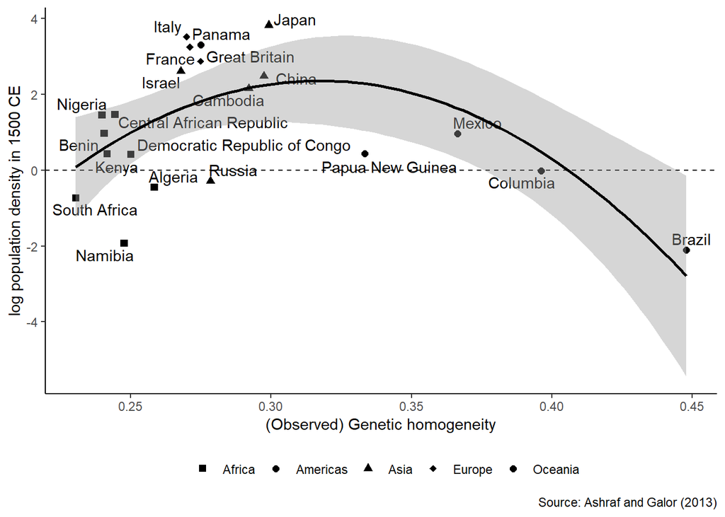

### Timeline of Jerusalem

Timeline of Jerusalem: Dotted lines - labels on y-axis

(Can change source here if you would prefer not to cite Wikipedia)

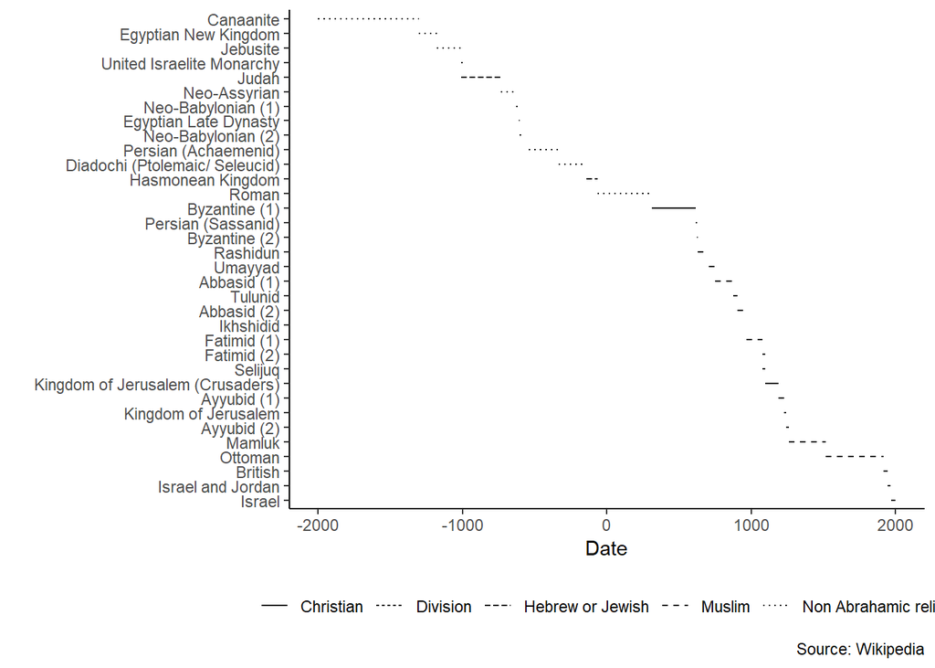

Timeline of Jerusalem: Shades of grey - labels on y-axis

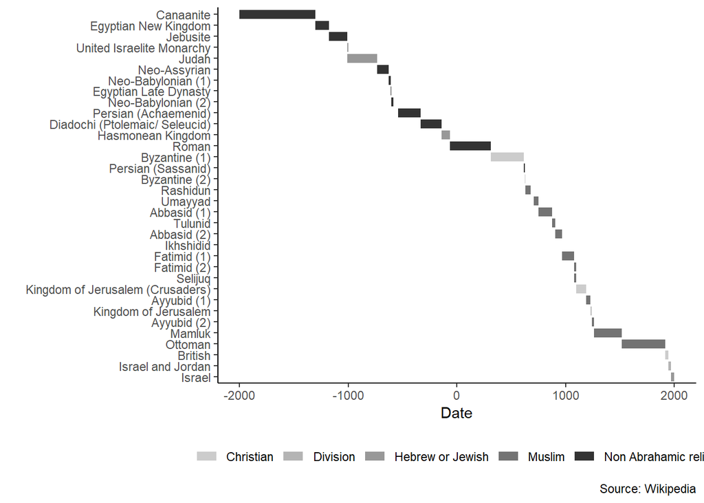

Timeline of Jerusalem: Alternate dotted lines - labels beside lines

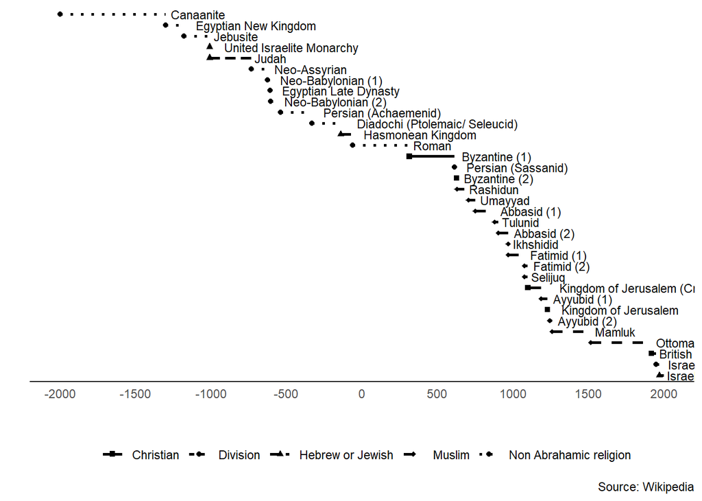

Timeline of Jerusalem: Alternate shades of grey - labels beside lines. Personally I like this one the most.

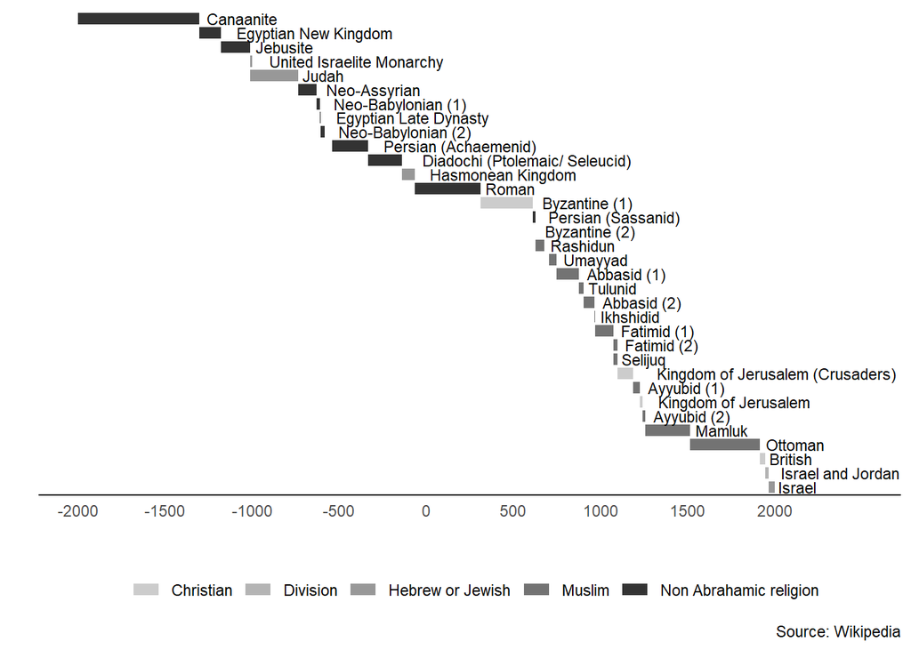

### Slave routes map

Slave routes map: No labels

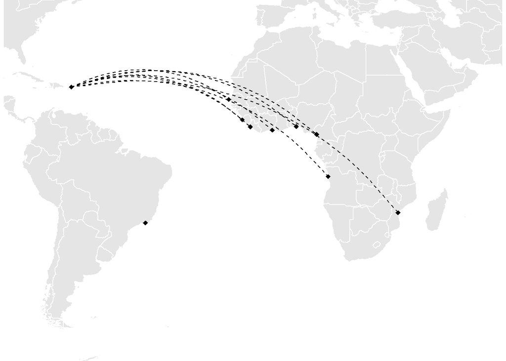

Slave routes map: Labels

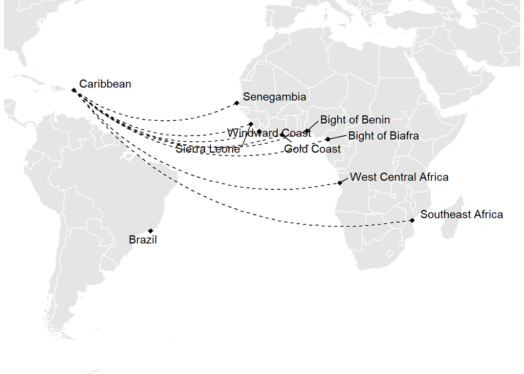

### Graph comparing USA and USSR growth:

Dotted lines

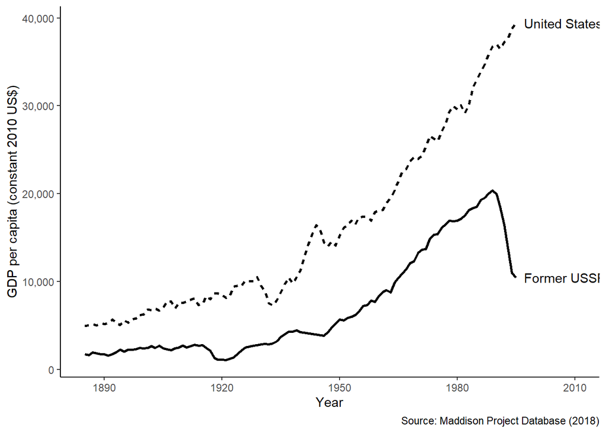

Grey lines. I can easily cut the series before the dip in the 1990s - if that’s preferable?

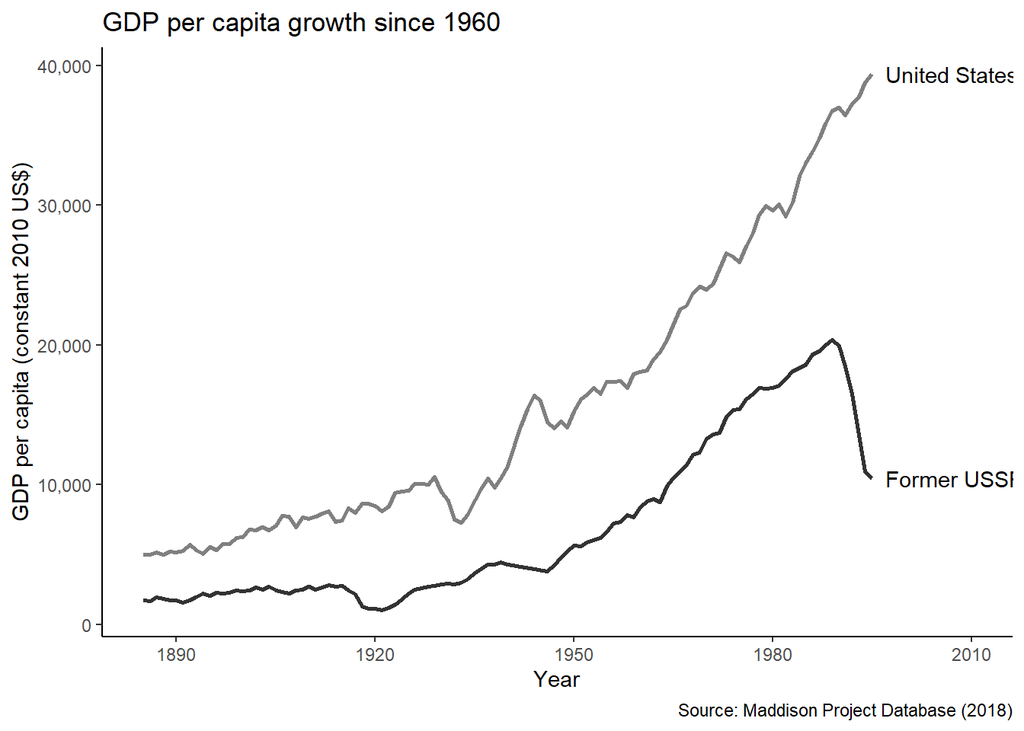

Dotted grey lines.

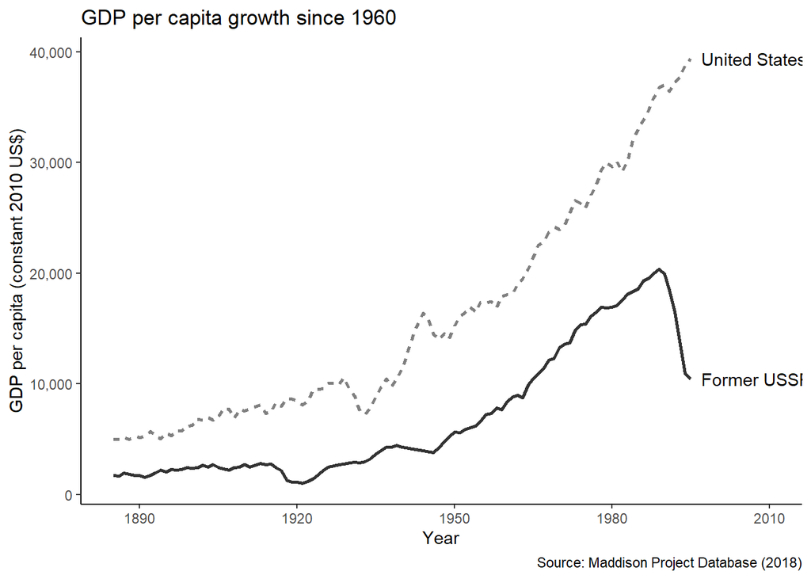

### Why does isiXhosa have clicks? The Bantu migration

Map of Bantu migration with lat and long lines

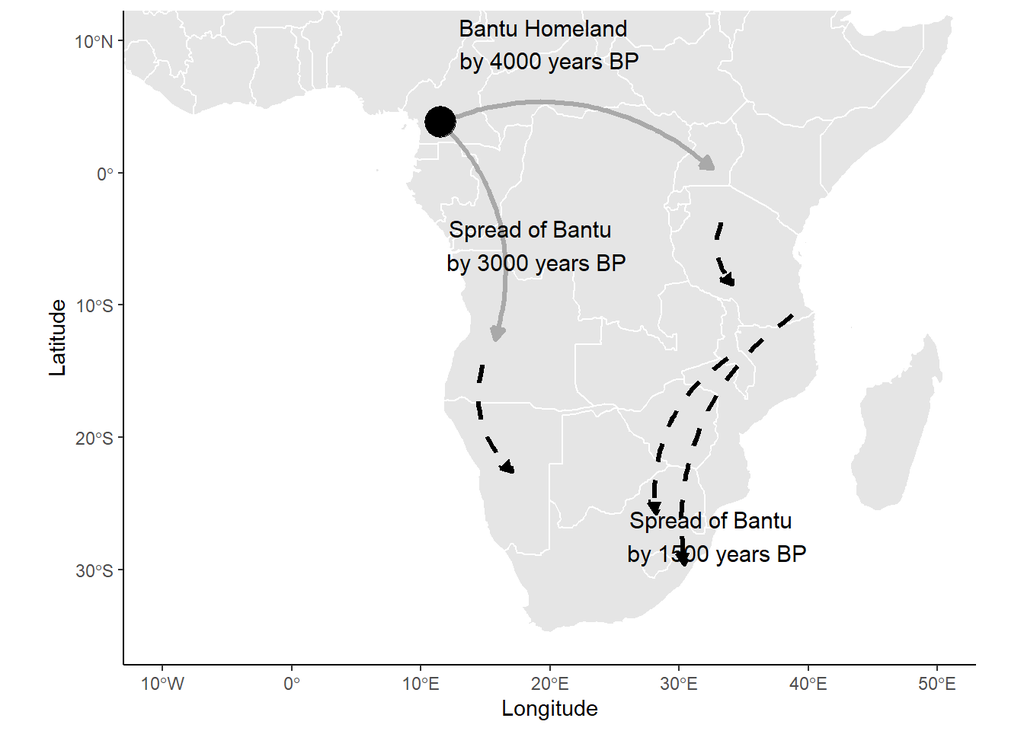

Without lat and long axes. This is a simplified version of the map that only includes the arrows, and copying the text from the original. Should this say “Bantu people” instead of “Bantu”?

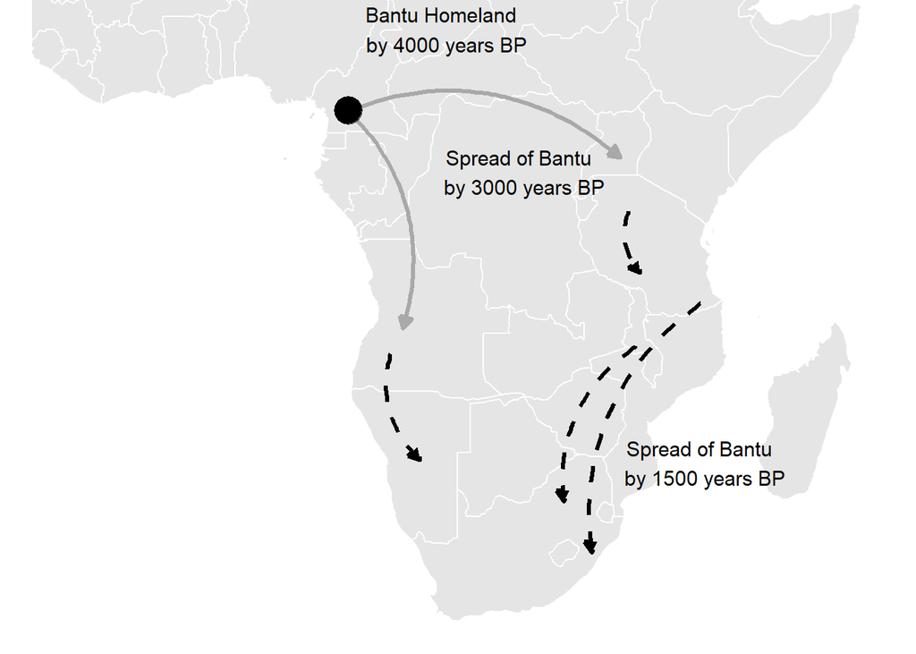